# Predicting customer product score by review text using LSTM and GRU recurent neural networks

## Brief description of the problem and data

The challange problem that will be addressed in this notebook is: given a data set of womens clothing reviews, which among other details includes the text of the review and the customer's score of the product, train a recurrent neural netwrk to predict what score a customer will give a product based on the text of their review.

The data in question is a collection of reviews posted on e-commerce platforms, with each review given to an article of womens clothing. Each sample contains the text of the review itself, the score the customer gave the product, how helpul other customers found the review, and other details as will be explored later.

## Data source

The data used in this notebook is from the "Women's E-Commerce Clothing Reviews" dataset, hosted on Kaggle.

URL to data set: https://www.kaggle.com/datasets/nicapotato/womens-ecommerce-clothing-reviews

```python
import numpy as np # linear algebra
import pandas as pd # data processing, CSV file I/O (e.g. pd.read_csv)
import tensorflow as tf
import keras
import keras_nlp

from sklearn.model_selection import train_test_split
from sklearn.metrics import ConfusionMatrixDisplay, confusion_matrix, f1_score, recall_score, precision_score

import seaborn as sns
import altair as alt
import matplotlib.pyplot as plt

import keras_tuner
import kerastuner
from keras_tuner.tuners import RandomSearch

from sklearn import feature_extraction, linear_model, model_selection, preprocessing

import nltk
from nltk.corpus import stopwords

import json
import os
import sys
import string
import re

os.environ["KERAS_BACKEND"] = "tensorflow"

print("TensorFlow version:", tf.__version__)
print(f"Keras Version: {keras.__version__}")
print("KerasNLP version:", keras_nlp.__version__)
print()
print(f"Python {sys.version}")
gpu_list = tf.config.list_physical_devices('GPU')
gpu = len(gpu_list)>0
print("GPU is", "available" if gpu else "NOT AVAILABLE")
print(gpu_list)
```

```
TensorFlow version: 2.10.0
Keras Version: 2.10.0
KerasNLP version: 0.6.1

Python 3.9.19 (main, Mar 21 2024, 17:21:27) [MSC v.1916 64 bit (AMD64)]
GPU is available
[PhysicalDevice(name='/physical_device:GPU:0', device_type='GPU')]
```

## Exploratory Data Analysis (EDA) — Inspect, Visualize and Clean the Data

### Data inspection

Below is a display of the first 5 samples of the data set.

```python
path_add = 'C:/Users/kgrit/OneDrive/Documents/UC boulder Data science masters/Intro to deep learning/final project/rough draft/'
df_reviews = pd.read_csv(path_add + "data/Womens Clothing E-Commerce Reviews.csv")
```

```python
print(df_reviews.shape)
display(df_reviews.head())
```

```
(23486, 11)
```

|  | Unnamed: 0 | Clothing ID | Age | Title | Review Text | Rating | Recommended IND | Positive Feedback Count | Division Name | Department Name | Class Name |
| --- | --- | --- | --- | --- | --- | --- | --- | --- | --- | --- | --- |
| 0 | 0 | 767 | 33 | NaN | Absolutely wonderful - silky and sexy and comf... | 4 | 1 | 0 | Initmates | Intimate | Intimates |
| 1 | 1 | 1080 | 34 | NaN | Love this dress! it's sooo pretty. i happene... | 5 | 1 | 4 | General | Dresses | Dresses |
| 2 | 2 | 1077 | 60 | Some major design flaws | I had such high hopes for this dress and reall... | 3 | 0 | 0 | General | Dresses | Dresses |
| 3 | 3 | 1049 | 50 | My favorite buy! | I love, love, love this jumpsuit. it's fun, fl... | 5 | 1 | 0 | General Petite | Bottoms | Pants |
| 4 | 4 | 847 | 47 | Flattering shirt | This shirt is very flattering to all due to th... | 5 | 1 | 6 | General | Tops | Blouses |

The only features relevent to this notebook are 'Review Text' and 'Rating', so those two will be pulled out and placed into a new dataframe. Additionally, rows with no review text or rating will be pulled at the beginning as a preemptive data cleaning operation.

```python
df_reviews_f = df_reviews[['Review Text', 'Rating']].copy().rename(columns={"Review Text":"text", "Rating":"rating"})
```

```python
df_reviews_f = df_reviews_f[df_reviews_f['text'].isnull() == False].copy()

display(df_reviews_f.head(n=5))
print('Dataframe shape:', df_reviews_f.shape)
print('rating without text: ',df_reviews_f[df_reviews_f['text'].isnull()].shape[0])
print('Text without rating: ',df_reviews_f[df_reviews_f['rating'].isnull()].shape[0])
```

|  | text | rating |
| --- | --- | --- |
| 0 | Absolutely wonderful - silky and sexy and comf... | 4 |
| 1 | Love this dress! it's sooo pretty. i happene... | 5 |
| 2 | I had such high hopes for this dress and reall... | 3 |
| 3 | I love, love, love this jumpsuit. it's fun, fl... | 5 |
| 4 | This shirt is very flattering to all due to th... | 5 |

```
Dataframe shape: (22641, 2)
rating without text:  0
Text without rating:  0
```

Of the data samples that have both text and rating, you can see that there are 22,641 samples that can be used in the following attampts. Lets move onto some statistics of the number of ratings for each possibler rating and the text lengths

### EDA - statistics and visualizations

First lets take a quick look at the length of the review texts, and some statistics of those lengths.

```python
def text_len(row):
    print(row["text"])
    return len(row["text"])
df_reviews_f["text_length"] = df_reviews_f['text'].apply(lambda x : len(x))

print("Full data set Stat\n")
df_reviews_f_len_desc = df_reviews_f["text_length"].describe()
print(df_reviews_f_len_desc)
```

```
Full data set Stat

count    22641.000000
mean       308.687911
std        143.940048
min          9.000000
25%        186.000000
50%        301.000000
75%        459.000000
max        508.000000
Name: text_length, dtype: float64
```

It looks like a large number of reveiw lengths are close to 300 characters, including spaces. However, if you look at the 75% quartile number, you can see that it is quite close to the max possible length. This could mean that a lot of review lengths tend towards the max length calculated. Lets look at histograms of the review lengths, broken up into 5 charts, one for each possible rating.

```python
def plot_histograms(df_in, col='text_length'):
    fig, ax = plt.subplots(2, 3, figsize=(20, 10))
    x = [df_in[df_in['rating'] == i] for i in range(1,6)]
    stats = [df[col].describe() for df in x]

    for i in range(5):
        ax_row = i // 3
        ax_col = i % 3
        n, bins, patches = ax[ax_row, ax_col].hist(x[i][col], 30, density=False)
        mu = stats[i]['mean']
        sigma = stats[i]['std']

        ax[ax_row, ax_col].axvline(mu, color='lightgreen')
        ax[ax_row, ax_col].axvline(stats[i]['25%'], color='magenta')
        ax[ax_row, ax_col].axvline(stats[i]['50%'], color='magenta')
        ax[ax_row, ax_col].axvline(stats[i]['75%'], color='magenta')

        max_c = np.max(n)/3
        if i == -1:
            print(n)
            print(bins)
            #475.46666667
            print(x[i][(x[i][col] < 490) & (x[i][col] > 475)])
            print(x[i][x[i][col] > 490].iloc[0,0])
        percs = ['25%', '50%', '75%']
        for j in range(3):
            ax[ax_row, ax_col].text(stats[i][percs[j]], max_c, percs[j], color='white', bbox=dict(boxstyle='square,pad=.2',facecolor='black'))
        #ax[i].text(stats[i]['50%'], max_c, '50%', color=t_color)
        #ax[i].text(stats[i]['75%'], max_c, '75%', color=t_color)
        #ax[i].axvline(stats[i]['25%'], color='orange')

        ax[ax_row, ax_col].set_xlabel('Review length')
        ax[ax_row, ax_col].set_ylabel('Review counts per given rating')

        ax[ax_row, ax_col].set_title(f'Histogram of Rating={i+1} reviews:\n'
                    fr'$\mu={mu:.0f}$, $\sigma={sigma:.0f}$, count={"{:,}".format(x[i].shape[0])}')
        ax[ax_row, ax_col].legend(['mean', 'quartiles'])

    # Tweak spacing to prevent clipping of ylabel
    fig.delaxes(ax[1][2])
    fig.tight_layout()
    plt.show()
```

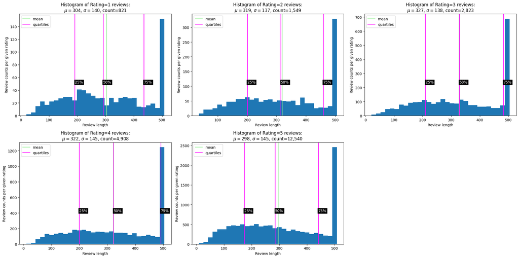

```python
plot_histograms(df_reviews_f)
```

As you can see, there are very large numbers of reviews for each possible review rating that are close to 500 characters. It is possible that these reviews have a large number of filler words, or stop words, that greatly exagerate the amount of meaningful words in the longer reviews. That will be where the majority of data cleaning will be focused.

### Data cleaning

Data cleaning will be comprised of removeing stop words from review texts, along with removing punctuation to simply text tokenization and make it easier for the RNN models to interpret reviews based on only vocabulary. I will also display the newly leaned review texts lengths in histograms of the same form as above. This will make it clear if the text cleaning smoothed out the distribution of text lengths.

```python
'''
def remove_stopword(text):
    remove_stopword = " ".join([word for word in text.split() if word.lower() not in stopwords.words('english')])

    return remove_stopword

df_reviews_f["text_clean"] = df_reviews_f["text"].apply(remove_stopword)

def clean_text(x):
    return re.sub(r"\s+", " ", x.translate(str.maketrans('', '', string.punctuation))).lower()

df_reviews_f["text_clean"] = df_reviews_f["text_clean"].apply(lambda x : clean_text(x))

df_reviews_f["length_clean"] = df_reviews_f["text_clean"].apply(lambda x : len(x))

#display(df_train["text_clean"].head())
#display(df_test["text_clean"].head())

df_reviews_f.to_csv("data/Womens Clothing E-Commerce Reviews - clean.csv", index=False)
'''
```

```python
df_reviews_f = pd.read_csv("data/Womens Clothing E-Commerce Reviews - clean.csv")
df_reviews_f.head()
```

|  | text | rating | text_length | text_clean | length_clean |
| --- | --- | --- | --- | --- | --- |
| 0 | Absolutely wonderful - silky and sexy and comf... | 4 | 53 | absolutely wonderful silky sexy comfortable | 43 |
| 1 | Love this dress! it's sooo pretty. i happene... | 5 | 303 | love dress sooo pretty happened find store im ... | 187 |
| 2 | I had such high hopes for this dress and reall... | 3 | 500 | high hopes dress really wanted work me initial... | 312 |
| 3 | I love, love, love this jumpsuit. it's fun, fl... | 5 | 124 | love love love jumpsuit fun flirty fabulous ev... | 92 |
| 4 | This shirt is very flattering to all due to th... | 5 | 192 | shirt flattering due adjustable front tie perf... | 112 |

Lets look at histogram charts again to view the text lengths distribution for each possible product rating

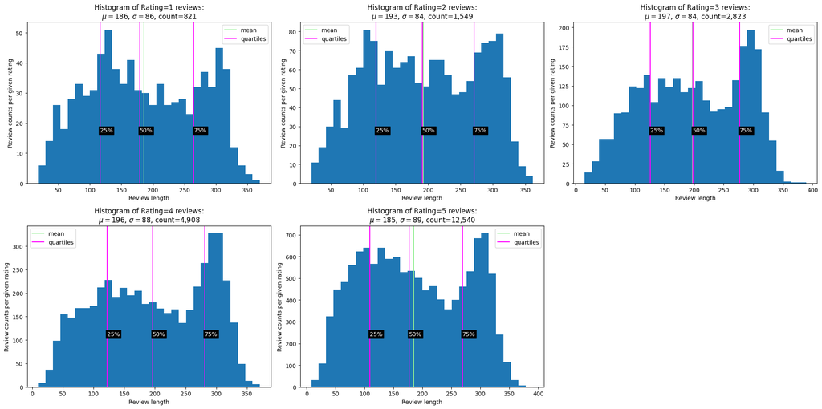

```python
plot_histograms(df_reviews_f, col='length_clean')
```

The text cleaning was able to smooth out the distributions quite a bit. Also, as you can see by looking at the spread of review length counts, the text cleaning brought every set of review texts into a similar spread of possible review lengths.

It appears that in almost every histogram there are two overlapping gaussian peaks in the data, one with a mean of about 300 and another with a mean of around 150. This could be because of the set of reviews with close to 500 characters. These reviews could have had proportional amounts of meaningful vocabulary in them when compared to the shorter reviews. We will keep all the reviews in one data set regardless. Future attempts to use the review texts here to predict review ratings could break the two sets of reivew lengths appeart and run model fitting on each one seperatly, or some other process.

### Data preprocessing and transformation

#### Splitting into testing, traing, and validation data

```python
df_reviews_f["rating_shifted"] = df_reviews_f['rating'].apply(lambda x: x - 1).values

df_train, df_test = train_test_split(
    df_reviews_f,
    test_size=0.2,
    random_state=42,
    stratify=df_reviews_f['rating'].values,)

df_val = df_train.sample(frac=0.3)
df_train.drop(df_val.index, inplace=True)
```

```python
def df_stats_print(df, df_title):
    print('\n' + df_title)
    #display(df.describe())
    for i in range(1, 6):
        _count = df[df['rating'] == i]['rating'].count()
        _total = df.shape[0]
        print(f"{i} counts: {_count}, % of total: {np.round(_count/_total*100,2)}")

df_stats_print(df_train, 'df_train')
df_stats_print(df_test, 'df_test')
df_stats_print(df_val, 'df_val')
#display(df_train.head())
```

```
df_train
1 counts: 479, % of total: 3.78
2 counts: 865, % of total: 6.82
3 counts: 1598, % of total: 12.6
4 counts: 2737, % of total: 21.59
5 counts: 6999, % of total: 55.21

df_test
1 counts: 164, % of total: 3.62
2 counts: 310, % of total: 6.84
3 counts: 565, % of total: 12.48
4 counts: 982, % of total: 21.68
5 counts: 2508, % of total: 55.38

df_val
1 counts: 178, % of total: 3.28
2 counts: 374, % of total: 6.88
3 counts: 660, % of total: 12.15
4 counts: 1189, % of total: 21.88
5 counts: 3033, % of total: 55.82
```

Above you can see that each possible rating value is proportionally represented in the training, validation, and testing data sets.

```python
max_features=5000
tokenizer=keras.preprocessing.text.Tokenizer(num_words=max_features,split=' ')
tokenizer.fit_on_texts(df_train['text_clean'].values)

X_train = tokenizer.texts_to_sequences(df_train['text_clean'].values)
X_train = keras.utils.pad_sequences(X_train)

X_val = tokenizer.texts_to_sequences(df_val['text_clean'].values)
X_val = keras.utils.pad_sequences(X_val, maxlen=X_train.shape[1])

X_test = tokenizer.texts_to_sequences(df_test['text_clean'].values)
X_test = keras.utils.pad_sequences(X_test,maxlen=X_train.shape[1])
```

To be able to pass the review ratings to the models, they must be formatted into arrays of shape (# of total labels) x (# of total samples) and the reviews need to be shifted down by 1 so that they start at zero. This is necessary for the evalutaion mettcs in the model fitting process to accuratly read the true labels. Each column of the new array will correspond to a given label by order, such that the first column corresponds to rating = 1, the second column to rating = 2, and so on.

```python
y_train = np.array([ [1 if row == i else 0 for i in range(5)] for row in df_train["rating_shifted"]])

y_val = np.array([ [1 if row == i else 0 for i in range(5)] for row in df_val["rating_shifted"]])

y_test = np.array([ [1 if row == i else 0 for i in range(5)] for row in df_test["rating_shifted"]])
#X_train, X_val, y_train, y_val = train_test_split(X, y, test_size=0.2, random_state=42)
```

```python
print(df_train['rating'].values[:5])
print(y_train[:5])
```

```
[5 1 5 4 5]
[[0 0 0 0 1]
 [1 0 0 0 0]
 [0 0 0 0 1]
 [0 0 0 1 0]
 [0 0 0 0 1]]
```

Below is a test of the tokenizer. The dictionary relating a column index to a specific word is retrived from the tokenizer and used to verify a given row of the formatted training data can be reconstructed (roughly) to match the original cleaned tweet.

```python
test_row = 20
print(X_train.shape)
print(X_val.shape)
print(y_train.shape)
print(y_val.shape)
print('test:\n    ', tokenizer.sequences_to_texts([X_train[test_row]]))
print('original cleaned tweet:\n    ', df_train.iloc[test_row]['text_clean'])
```

```
(12678, 61)
(5434, 61)
(12678, 5)
(5434, 5)
test:
     ['made wedding outfit perfect']
original cleaned tweet:
     made wedding outfit perfect
```

Looks good.

### Model architectures

#### Long-Short Term Memory (LSTM) architecture

This will be a 2-layer LSTM model. To help address overfitting, dropout layers are added directly before, between, after each layer. The metric to maximize in training is multi-label AUC average. The reasoning to use AUC is that since these reviews are being judged as being any one of 5 different possible scores, and to keep the model from over-prioritizing one review rating label right, you can score a model by getting the AUC for each label, then averaging the scores.

```python
def lstm_model(hp):

    poss_units = [8,16,32,64, 128]
    hp_ltsm_units_1 = hp.Choice("ltsm_memory_units_layer_1", poss_units)
    hp_ltsm_units_2 = hp.Choice("ltsm_memory_units_layer_2", poss_units)

    poss_dropouts = [0.0, 0.1, 0.2, 0.3, 0.4]
    hp_dropout_frac_1 = hp.Choice("dropout_rate_layer_1", poss_dropouts)
    hp_dropout_frac_2 = hp.Choice("dropout_rate_layer_2", poss_dropouts)
    hp_dropout_frac_3 = hp.Choice("dropout_rate_layer_3", poss_dropouts)

    embed_dim = 100

    model = keras.models.Sequential([
        keras.layers.Embedding(max_features, embed_dim, input_length = X_train.shape[1]),
        keras.layers.Dropout(hp_dropout_frac_1),
        keras.layers.LSTM(hp_ltsm_units_1, return_sequences=True, name="LSTM_layer_1"),
        keras.layers.Dropout(hp_dropout_frac_2),
        keras.layers.LSTM(hp_ltsm_units_2, name="LSTM_layer_2"),
        keras.layers.Dropout(hp_dropout_frac_3),
        keras.layers.Dense(5,activation='softmax'),
        ])

    hp_lr = hp.Choice("learning_rate", [1e-2, 1e-3, 1e-4, 1e-5])

    model.compile(
        loss=keras.losses.CategoricalCrossentropy(),
        optimizer=keras.optimizers.Adam(learning_rate=hp_lr),
        metrics= [keras.metrics.AUC(multi_label=True, num_labels=5, name='auc', from_logits=True)]
    )

    return model
```

#### GRU 1-layer architecture

This will be a single layer GRU model. To help address overfitting, dropout layers are added directly before and after. The metric to maximize in training is multi-label AUC average

```python
def gru_1_layer_model(hp):

    embed_dim = 100

    poss_units = [8,16,32,64,128,256,512]
    hp_gru_units_1 = hp.Choice("gru_memory_units_layer_1", poss_units)

    poss_dropouts = [0.0, 0.1, 0.2, 0.3, 0.4]
    hp_dropout_frac_1 = hp.Choice("dropout_rate_layer_1", poss_dropouts)
    hp_dropout_frac_2 = hp.Choice("dropout_rate_layer_2", poss_dropouts)

    model = keras.models.Sequential()
    model.add(keras.layers.Embedding(max_features, embed_dim, input_length = X_train.shape[1]))
    model.add(keras.layers.Dropout(hp_dropout_frac_1))
    model.add(tf.keras.layers.GRU(hp_gru_units_1))
    model.add(keras.layers.Dropout(hp_dropout_frac_2))
    model.add(keras.layers.Dense(5,activation='softmax'))


    hp_lr = hp.Choice("learning_rate", [1e-2, 1e-3, 1e-4, 1e-5])

    model.compile(
        loss=keras.losses.CategoricalCrossentropy(),
        optimizer=keras.optimizers.Adam(learning_rate=hp_lr),
        metrics= [keras.metrics.AUC(multi_label=True, num_labels=5, name='auc', from_logits=True)]
    )

    return model
```

#### GRU 2-layer architecture

This will be a two layer GRU model. To help address overfitting, dropout layers are added directly before and after. The metric to maximize in training is multi-label AUC average

```python
def gru_model(hp):

    embed_dim = 100

    poss_units = [8,16,32,64]
    hp_gru_units_1 = hp.Choice("gru_memory_units_layer_1", poss_units)
    hp_gru_units_2 = hp.Choice("gru_memory_units_layer_2", poss_units)

    poss_dropouts = [0.0, 0.1, 0.2, 0.3, 0.4]
    hp_dropout_frac_1 = hp.Choice("dropout_rate_layer_1", poss_dropouts)
    hp_dropout_frac_2 = hp.Choice("dropout_rate_layer_2", poss_dropouts)
    hp_dropout_frac_3 = hp.Choice("dropout_rate_layer_3", poss_dropouts)

    model = keras.models.Sequential()
    model.add(keras.layers.Embedding(max_features, embed_dim, input_length = X_train.shape[1]))
    model.add(keras.layers.Dropout(hp_dropout_frac_1))
    model.add(tf.keras.layers.GRU(hp_gru_units_1, return_sequences=True, ))
    model.add(keras.layers.Dropout(hp_dropout_frac_2))
    model.add(tf.keras.layers.GRU(hp_gru_units_2))
    model.add(keras.layers.Dropout(hp_dropout_frac_3))
    model.add(keras.layers.Dense(5,activation='softmax'))


    hp_lr = hp.Choice("learning_rate", [1e-2, 1e-3, 1e-4, 1e-5])

    model.compile(
        loss=keras.losses.CategoricalCrossentropy(),
        optimizer=keras.optimizers.Adam(learning_rate=hp_lr),
        metrics= [keras.metrics.AUC(multi_label=True, num_labels=5, name='auc', from_logits=True)]
    )

    return model
```

#### GRU 4 layer

This will be a four layer GRU model. To help address overfitting, dropout layers are added directly before and after. The metric to maximize in training is multi-label AUC average

```python
def gru_4_layer_model(hp):

    embed_dim = 100
    4*4*5*5*4
    poss_units = [8,16,32,64]
    hp_gru_units_1 = hp.Choice("gru_memory_units_layer_1", poss_units)
    hp_gru_units_2 = hp.Choice("gru_memory_units_layer_2", poss_units)
    hp_gru_units_3 = hp.Choice("gru_memory_units_layer_3", poss_units)
    hp_gru_units_4 = hp.Choice("gru_memory_units_layer_4", poss_units)

    poss_dropouts = [0.0, 0.1, 0.2, 0.3, 0.4]
    hp_dropout_frac_1 = hp.Choice("dropout_rate_layer_1", poss_dropouts)
    hp_dropout_frac_2 = hp.Choice("dropout_rate_layer_2", poss_dropouts)
    hp_dropout_frac_3 = hp.Choice("dropout_rate_layer_3", poss_dropouts)
    hp_dropout_frac_4 = hp.Choice("dropout_rate_layer_4", poss_dropouts)
    hp_dropout_frac_5 = hp.Choice("dropout_rate_layer_5", poss_dropouts)

    model = keras.models.Sequential()
    model.add(keras.layers.Embedding(max_features, embed_dim, input_length = X_train.shape[1]))
    model.add(keras.layers.Dropout(hp_dropout_frac_1))
    model.add(tf.keras.layers.GRU(hp_gru_units_1, return_sequences=True))
    model.add(keras.layers.Dropout(hp_dropout_frac_2))
    model.add(tf.keras.layers.GRU(hp_gru_units_2, return_sequences=True))
    model.add(keras.layers.Dropout(hp_dropout_frac_3))
    model.add(tf.keras.layers.GRU(hp_gru_units_3, return_sequences=True))
    model.add(keras.layers.Dropout(hp_dropout_frac_4))
    model.add(tf.keras.layers.GRU(hp_gru_units_4))
    model.add(keras.layers.Dropout(hp_dropout_frac_5))
    model.add(keras.layers.Dense(5,activation='softmax'))


    hp_lr = hp.Choice("learning_rate", [1e-2, 1e-3, 1e-4, 1e-5])

    model.compile(
        loss=keras.losses.CategoricalCrossentropy(),
        optimizer=keras.optimizers.Adam(learning_rate=hp_lr),
        metrics= [keras.metrics.AUC(multi_label=True, num_labels=5, name='auc', from_logits=True)]
    )

    return model
```

### Tuners to find optimal hyperparametrs

Below are the different hyperparameter tuners for each of the models defined above. Each tuner will randomly select 50 different sets of possible hyperparameters for each model, train each of the 50 models for 3 epochs, then sgrade these 50 models based on total AUC score.

```python
tuner_files_dir = 'C:/Users/kgrit/OneDrive/Documents/UC boulder Data science masters/Intro to deep learning/final project/rough draft'
t_objective = kerastuner.Objective('auc', direction='max')
t_max_trials = 50
t_overwrite = False
t_executions_per_trial = 1
```

#### LSTM tuner

```python
tuner_lstm = RandomSearch(
    lstm_model,
    objective=t_objective,
    max_trials=t_max_trials,
    overwrite=t_overwrite,
    executions_per_trial=t_executions_per_trial,
    directory=tuner_files_dir,
    project_name='lstm_model')
```

```
Reloading Tuner from C:/Users/kgrit/OneDrive/Documents/UC boulder Data science masters/Intro to deep learning/final project/rough draft\lstm_model\tuner0.json
```

#### GRU 1-layer tuner

```python
tuner_gru_1_layer = RandomSearch(
    gru_1_layer_model,
    objective=t_objective,
    max_trials=t_max_trials,
    overwrite=t_overwrite,
    executions_per_trial=t_executions_per_trial,
    directory=tuner_files_dir,
    project_name='gru_1_layer_model')
```

#### GRU 2-layer tuner

```python
tuner_gru = RandomSearch(
    gru_model,
    objective=t_objective,
    max_trials=t_max_trials,
    overwrite=t_overwrite,
    executions_per_trial=t_executions_per_trial,
    directory=tuner_files_dir,
    project_name='gru_model')
```

#### GRU 4-layer tuner

```python
tuner_gru_4_L = RandomSearch(
    gru_4_layer_model,
    objective=t_objective,
    max_trials=t_max_trials,
    overwrite=t_overwrite,
    executions_per_trial=t_executions_per_trial,
    directory=tuner_files_dir,
    project_name='gru_4_layer_model')
```

```
Reloading Tuner from C:/Users/kgrit/OneDrive/Documents/UC boulder Data science masters/Intro to deep learning/final project/rough draft\gru_4_layer_model\tuner0.json
```

## Results and Analysis

Now lets run the tuners and find the best set of hyperparameters for each model architecture. Below is code to retrive parameters from previous trials.

#### LSTM 2 layer tuner results

```python
tuner_lstm.search(X_train, y_train, epochs=3, validation_data=(X_val, y_val))
```

```
Trial 50 Complete [00h 00m 19s]
auc: 0.5106742978096008

Best auc So Far: 0.8990048170089722
Total elapsed time: 00h 22m 13s
```

```python
models_lstm = tuner_lstm.get_best_models(num_models=5)
best_model_lstm = models_lstm[0]
best_hps_lstm = tuner_lstm.get_best_hyperparameters(1)[0]
print(best_hps_lstm.values)
best_model_lstm.summary()
```

[output not shown]

#### GRU 1 layer tuner results

```python
with tf.device('/GPU:0'):
    tuner_gru_1_layer.search(X_train, y_train, epochs=3, validation_data=(X_val, y_val))
```

```
Trial 50 Complete [00h 00m 13s]
auc: 0.6010494232177734

Best auc So Far: 0.9196551442146301
Total elapsed time: 00h 13m 55s
```

```python
models_gru_1_layer = tuner_gru_1_layer.get_best_models(num_models=5)
best_model_gru_1_layer = models_gru_1_layer[0]
best_hps_gru_1_layer = tuner_gru_1_layer.get_best_hyperparameters(1)[0]
print(best_hps_gru_1_layer.values)
best_model_gru_1_layer.summary()
```

```
{'gru_memory_units_layer_1': 256, 'dropout_rate_layer_1': 0.3, 'dropout_rate_layer_2': 0.0, 'learning_rate': 0.01}
Model: "sequential"
_________________________________________________________________
 Layer (type)                Output Shape              Param #
=================================================================
 embedding (Embedding)       (None, 61, 100)           500000

 dropout (Dropout)           (None, 61, 100)           0

 gru (GRU)                   (None, 256)               274944

 dropout_1 (Dropout)         (None, 256)               0

 dense (Dense)               (None, 5)                 1285

=================================================================
Total params: 776,229
Trainable params: 776,229
Non-trainable params: 0
_________________________________________________________________
_________________________________________________________________
 Layer (type)                Output Shape              Param #
=================================================================
 embedding (Embedding)       (None, 61, 100)           500000

 dropout (Dropout)           (None, 61, 100)           0

 gru (GRU)                   (None, 256)               274944

 dropout_1 (Dropout)         (None, 256)               0

 dense (Dense)               (None, 5)                 1285

=================================================================
Total params: 776,229
Trainable params: 776,229
Non-trainable params: 0
_________________________________________________________________
```

#### GRU 2 layer tuner results

```python
with tf.device('/GPU:0'):
    tuner_gru.search(X_train, y_train, epochs=3, validation_data=(X_val, y_val))
```

```
Trial 50 Complete [00h 00m 29s]
auc: 0.5173693895339966

Best auc So Far: 0.9008854627609253
Total elapsed time: 00h 17m 44s
```

```python
models_gru = tuner_gru.get_best_models(num_models=5)
best_model_gru = models_gru[0]
best_hps_gru = tuner_gru.get_best_hyperparameters(1)[0]
print(best_hps_gru.values)
best_model_gru.summary()
```

```
{'gru_memory_units_layer_1': 8, 'gru_memory_units_layer_2': 16, 'dropout_rate_layer_1': 0.1, 'dropout_rate_layer_2': 0.0, 'dropout_rate_layer_3': 0.2, 'learning_rate': 0.01}
Model: "sequential"
_________________________________________________________________
 Layer (type)                Output Shape              Param #
=================================================================
 embedding (Embedding)       (None, 61, 100)           500000

 dropout (Dropout)           (None, 61, 100)           0

 gru (GRU)                   (None, 61, 8)             2640

 dropout_1 (Dropout)         (None, 61, 8)             0

 gru_1 (GRU)                 (None, 16)                1248

 dropout_2 (Dropout)         (None, 16)                0

 dense (Dense)               (None, 5)                 85

=================================================================
Total params: 503,973
Trainable params: 503,973
Non-trainable params: 0
_________________________________________________________________
_________________________________________________________________
 Layer (type)                Output Shape              Param #
=================================================================
 embedding (Embedding)       (None, 61, 100)           500000

 dropout (Dropout)           (None, 61, 100)           0

 gru (GRU)                   (None, 61, 8)             2640

 dropout_1 (Dropout)         (None, 61, 8)             0

 gru_1 (GRU)                 (None, 16)                1248

 dropout_2 (Dropout)         (None, 16)                0

 dense (Dense)               (None, 5)                 85

=================================================================
Total params: 503,973
Trainable params: 503,973
Non-trainable params: 0
_________________________________________________________________
```

#### GRU 4 layer tuner results

```python
tuner_gru_4_L.search(X_train, y_train, epochs=3, validation_data=(X_val, y_val))
```

```
Trial 50 Complete [00h 00m 31s]
auc: 0.5377457737922668

Best auc So Far: 0.8823961019515991
Total elapsed time: 00h 39m 30s
```

```python
models_gru_4_L = tuner_gru_4_L.get_best_models(num_models=5)
best_model_gru_4_L = models_gru_4_L[0]
best_hps_gru_4_L = tuner_gru_4_L.get_best_hyperparameters(1)[0]
print(best_hps_gru_4_L.values)
best_model_gru_4_L.summary()
```

[output not shown]

Below are reprints of the optimal prameters found for each model architecture

```python
print('\nLSTM 2 layer tuner results')
display(best_hps_lstm.values)
print('\nGRU 1 layer tuner results')
display(best_hps_gru_1_layer.values)
print('\nGRU 2 layer tuner results')
display(best_hps_gru.values)
print('\nGRU 4 layer tuner results')
display(best_hps_gru_4_L.values)
```

```
LSTM 2 layer tuner results
```

```
{'ltsm_memory_units_layer_1': 64,
 'ltsm_memory_units_layer_2': 128,
 'dropout_rate_layer_1': 0.1,
 'dropout_rate_layer_2': 0.3,
 'dropout_rate_layer_3': 0.1,
 'learning_rate': 0.001}
```

```
GRU 1 layer tuner results
```

```
{'gru_memory_units_layer_1': 256,
 'dropout_rate_layer_1': 0.3,
 'dropout_rate_layer_2': 0.0,
 'learning_rate': 0.01}
```

```
GRU 2 layer tuner results
```

```
{'gru_memory_units_layer_1': 8,
 'gru_memory_units_layer_2': 16,
 'dropout_rate_layer_1': 0.1,
 'dropout_rate_layer_2': 0.0,
 'dropout_rate_layer_3': 0.2,
 'learning_rate': 0.01}
```

```
GRU 4 layer tuner results
```

```
{'gru_memory_units_layer_1': 8,
 'gru_memory_units_layer_2': 32,
 'gru_memory_units_layer_3': 32,
 'gru_memory_units_layer_4': 32,
 'dropout_rate_layer_1': 0.3,
 'dropout_rate_layer_2': 0.0,
 'dropout_rate_layer_3': 0.0,
 'dropout_rate_layer_4': 0.0,
 'dropout_rate_layer_5': 0.2,
 'learning_rate': 0.01}
```

### Best model fitting for LTSM, GRU, and 4-layer GRU models

```python
batch_size = 32
epochs = 15
early_stopping_p = 5
```

```python
callbacks_lstm = [
    keras.callbacks.ModelCheckpoint(filepath="final_lstm_model\model_at_epoch_{epoch}.keras"),
    keras.callbacks.EarlyStopping(monitor="val_loss", patience=early_stopping_p, restore_best_weights=True),
]

final_lstm_model = lstm_model(best_hps_lstm)

final_lstm_model_history = final_lstm_model.fit(
    X_train,
    y_train,
    validation_data=(X_val, y_val),
    batch_size=batch_size,
    epochs=epochs,
    callbacks=callbacks_lstm,
)
```

```python
final_lstm_model.save("final_lstm_model/final_lstm_model.keras")
```

```python
callbacks_gru_1_layer = [
    keras.callbacks.ModelCheckpoint(filepath="final_gru_1_layer_model\model_at_epoch_{epoch}.keras"),
    keras.callbacks.EarlyStopping(monitor="val_loss", patience=early_stopping_p, restore_best_weights=True),
]

final_gru_1_layer_model = gru_1_layer_model(best_hps_gru_1_layer)

final_gru_1_layer_model_history = final_gru_1_layer_model.fit(
    X_train,
    y_train,
    validation_data=(X_val, y_val),
    batch_size=batch_size,
    epochs=epochs,
    callbacks=callbacks_gru_1_layer,
)
```

```python
final_gru_1_layer_model.save("final_gru_model/final_gru_1_layer_model.keras")
```

```python
callbacks_gru = [
    keras.callbacks.ModelCheckpoint(filepath="final_gru_model\model_at_epoch_{epoch}.keras"),
    keras.callbacks.EarlyStopping(monitor="val_loss", patience=early_stopping_p, restore_best_weights=True),
]

final_gru_model = gru_model(best_hps_gru)

final_gru_model_history = final_gru_model.fit(
    X_train,
    y_train,
    validation_data=(X_val, y_val),
    batch_size=batch_size,
    epochs=epochs,
    callbacks=callbacks_gru,
)
```

```python
final_gru_model.save("final_gru_model/final_gru_2_layer_model.keras")
```

```python
callbacks_gru_4_L = [
    keras.callbacks.ModelCheckpoint(filepath="final_gru_4_l_model\model_at_epoch_{epoch}.keras"),
    keras.callbacks.EarlyStopping(monitor="val_loss", patience=early_stopping_p, restore_best_weights=True),
]

final_gru_4_L_model = gru_4_layer_model(best_hps_gru_4_L)

final_gru_model_history = final_gru_4_L_model.fit(
    X_train,
    y_train,
    validation_data=(X_val, y_val),
    batch_size=batch_size,
    epochs=epochs,
    callbacks=callbacks_gru_4_L,
)
```

```python
final_gru_4_L_model.save("final_gru_4_l_model/final_gru_4_L_model.keras")
```

## Results and Analysis (35 pts)

### Final model confusion matrices

Below are confusion matrices that showcase how each final model did when predicting the rating given with a particular review text, for both training and validation data set predictions.

```python
def get_labels(vals_in):
        list_out = [0 for i in vals_in]
        for i in range(len(vals_in)):
            list_out[i] = np.argmax(vals_in[i]) + 1
        return list_out

def displayConfusionMatrix(y_true_train, y_pred_train, model=None, data_set=None, y_true_val=None, y_pred_val=None):



    num_cols = 1
    if y_true_val is not None:
        num_cols = 2
        y_true_val_f = get_labels(y_true_val)
        y_pred_val_f = get_labels(y_pred_val)

    fig, ax = plt.subplots(1,num_cols, figsize=(10, 4))

    y_true_train_f = get_labels(y_true_train)
    y_pred_train_f = get_labels(y_pred_train)

    ax_in = None
    if y_true_val is not None:
        ax_in = ax[0]
    else:
        ax_in = ax

    disp_1 = ConfusionMatrixDisplay.from_predictions(
        y_true_train_f,
        y_pred_train_f,
        normalize='true',
        values_format=".2f",
        ax=ax_in, cmap=plt.cm.Blues
    )

    if y_true_val is not None:
        disp_2 = ConfusionMatrixDisplay.from_predictions(
            y_true_val_f,
            y_pred_val_f,
            normalize='true',
            values_format=".2f",
            ax=ax[1], cmap=plt.cm.Greens
        )

        f1_score_val = f1_score(y_true_val_f, y_pred_val_f, average='weighted')
        recall_score_val = recall_score(y_true_val_f, y_pred_val_f, average='weighted')
        prec_score_val = precision_score(y_true_val_f, y_pred_val_f, average='weighted')

        disp_2.ax_.set_title(f"{model} - Validation Dataset\nF1: {str(f1_score_val.round(3))}\nRecall: {str(recall_score_val.round(3))}\nPrecision: {str(prec_score_val.round(3))}")

    f1_score_pred = f1_score(y_true_train_f, y_pred_train_f, average='weighted')
    recall_score_pred = recall_score(y_true_train_f, y_pred_train_f, average='weighted')
    prec_score_pred = precision_score(y_true_train_f, y_pred_train_f, average='weighted')
    title = None
    if data_set is not None:
        title = data_set
    else:
        title = 'Training'
    disp_1.ax_.set_title(f"{model} - {title} Dataset\nF1: {str(f1_score_pred.round(3))}\nRecall: {str(recall_score_pred.round(3))}\nPrecision: {str(prec_score_pred.round(3))}")

    fig.tight_layout()
```

```python
def plot_proportions(true, pred, val):
    fig, ax = plt.subplots(layout='constrained', figsize=(8, 4))

    y_train_labels_counts = np.unique(get_labels(true), return_counts=True)
    y_pred_labels_counts = np.unique(get_labels(pred), return_counts=True)
    y_val_label_counts = None

    if val is not None:
        y_val_label_counts = np.unique(get_labels(val), return_counts=True)

    def get_vals(list_in):
        return_y = [0,0,0,0,0]
        ind = 0
        for i in range(5):
            if len(np.where(list_in[0][ind] == i + 1)[0]) > 0:
                return_y[i] = list_in[1][ind]
                ind+=1
        return return_y

    y_1 = get_vals(y_pred_labels_counts)
    y_2 = None
    if val is not None:
        y_2 = get_vals(y_val_label_counts)

    rating = ("1", "2", "3", '4', '5')
    pop = None
    if val is not None:
        pop = {
            'true proportions': np.round((y_train_labels_counts[1]/sum(y_train_labels_counts[1])), 2),
            'pred proportions': np.round((y_1/sum(y_1)), 2),
            'val proportions': np.round((y_2/sum(y_2)), 2),
        }
    else:
        pop = {
            'true proportions': np.round((y_train_labels_counts[1]/sum(y_train_labels_counts[1])), 2),
            'pred proportions': np.round((y_1/sum(y_1)), 2)
        }

    x = y_train_labels_counts[0]  # the label locations
    width = 0.25  # the width of the bars
    multiplier = 0
    color = ['salmon', 'skyblue', 'lightgreen']
    c_ind = 0
    for att, vals in pop.items():
        offset = width * multiplier
        rects = ax.bar(x + offset, vals, width, label=att, color=color[c_ind])
        ax.bar_label(rects, padding=3)
        multiplier += 1
        c_ind += 1

    # Add some text for labels, title and custom x-axis tick labels, etc.
    ax.set_ylabel('Predictions per rating (scaled)')
    ax.set_title('Rating')
    ax.set_xticks(x + width, rating)
    ax.legend(loc='upper left', ncols=1)
    #ax.set_ylim(0, 250)

    plt.show()
```

### Assessment of LSTM model

```python
y_pred_train_lstm = final_lstm_model.predict(X_train)
y_pred_val_lstm = final_lstm_model.predict(X_val)
```

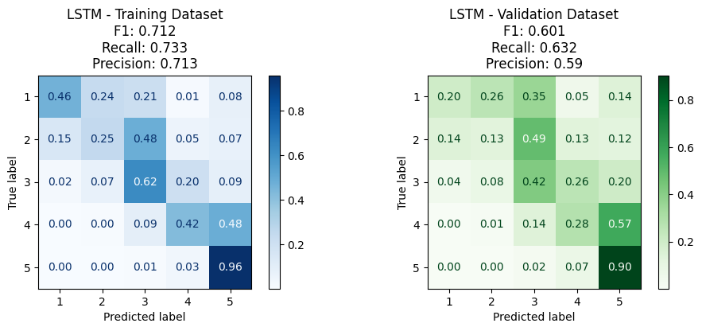

```python
displayConfusionMatrix(y_train, y_pred_train_lstm,  model='LSTM', y_true_val=y_val, y_pred_val=y_pred_val_lstm,)
```

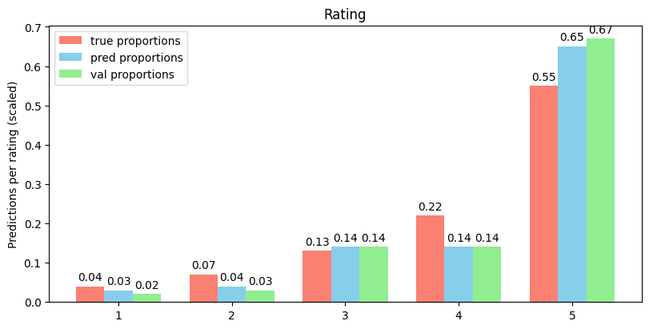

```python
plot_proportions(y_train, y_pred_train_lstm, y_pred_val_lstm)
```

Here you can see that the best final model did very well accuratly labeling review texts that were rated 5 star and did decently overall. It was able to score highest in the correct label categroies for 3 of the 5 labels, and had a little cross over in neighboring labels. For example, for reviews that were truly 4 star reviews, the model predicted their labels as either 3, 4, or 5, with most being 4 or 5. None or practically none of the 4 star reviews were ever predicted to be 1 or 2 star reviews.

### Assessment of 1-layer GRU model

```python
y_pred_train_gru_1_layer = final_gru_1_layer_model.predict(X_train)
y_pred_val_gru_1_layer = final_gru_1_layer_model.predict(X_val)
```

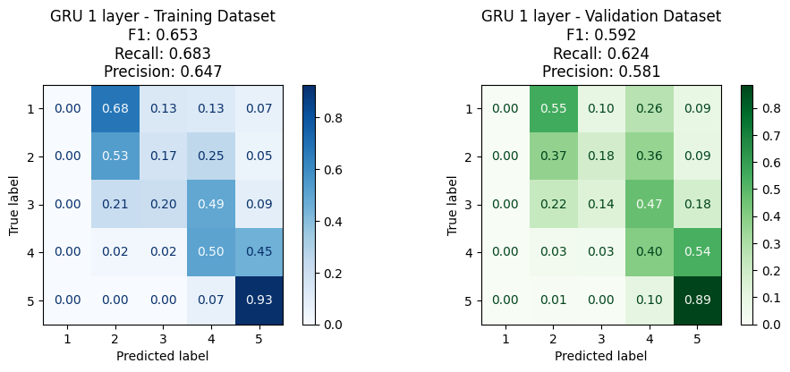

```python
displayConfusionMatrix(y_train, y_pred_train_gru_1_layer, model='GRU 1 layer', y_true_val=y_val, y_pred_val=y_pred_val_gru_1_layer)
```

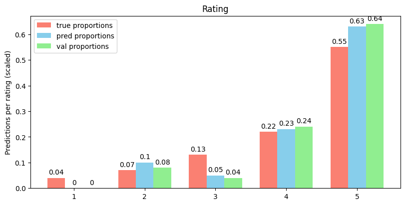

```python
plot_proportions(y_train, y_pred_train_gru_1_layer, y_pred_val_gru_1_layer)
```

Here you can see the 1-layer GRU model predicted that most of the labels would be either 2, 4, or 5. This model also did well with predicting what was actaully a 5 star review but stuggled with the others. A potential reason why it was able to get as many 2 and 4 star reviews correct as it did was because its fitting and focused on 2, 4, and 5 star labels at the expense of 1 and 3 star reviews.

### Assessment of 2-layer GRU model

```python
y_pred_train_gru = final_gru_model.predict(X_train)
y_pred_val_gru = final_gru_model.predict(X_val)
```

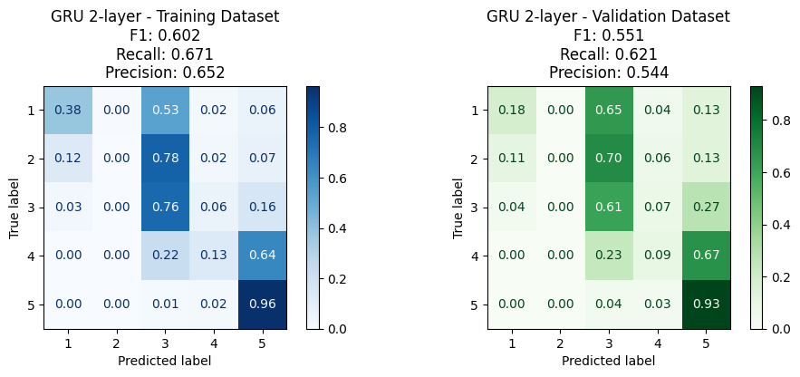

```python
displayConfusionMatrix(y_train, y_pred_train_gru, y_true_val=y_val, y_pred_val=y_pred_val_gru, model='GRU 2-layer')
```

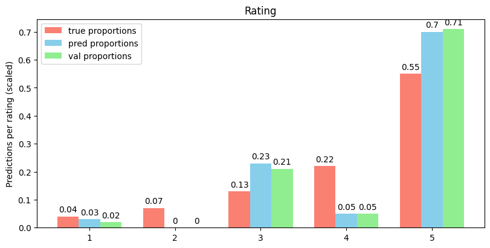

```python
plot_proportions(y_train, y_pred_train_gru, y_pred_val_gru)
```

As with the 1-layer GRU model, the 2-layer GRU focused on getting just 3 layers right. It predicted that most of the labels would be either 1, 3, or 5. As before, the model also did well with predicting what was actaully a 5 star review but stuggled with the others.

### Assessment of GRU 4-layer model

```python
y_pred_train_gru_4L = final_gru_4_L_model.predict(X_train)
y_pred_val_gru_4L = final_gru_4_L_model.predict(X_val)
```

[figure not shown]

```python
displayConfusionMatrix(y_train, y_pred_train_gru, y_true_val=y_val, y_pred_val=y_pred_val_gru_4L, model='GRU 4-layer')
```

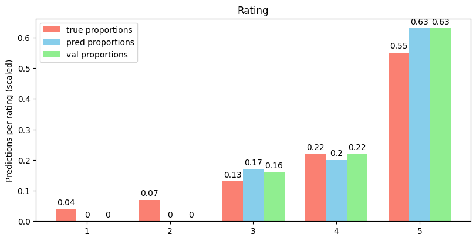

```python
plot_proportions(y_train, y_pred_train_gru_4L, y_pred_val_gru_4L)
```

Finally, we have the 4-layer GRU model. As with the 1-layer and 2-layer GRU model, the 4-layer GRU focused on getting just 3 layers right. It predicted that most of the labels would be either 3, 4, or 5. As before, the model also did well with predicting what was actaully a 5 star review but stuggled with the others.

### Final test prediction and score for best performing model

```python
for i in range(5,8):
    print(f'row {i}')
    print('test:\n    ', tokenizer.sequences_to_texts([final_test[i]]))
    print('original cleaned tweet:\n    ', df_test.iloc[i]['text_clean'])
```

```
row 5
test:
     ['bought green thought bit different super flattering fabric soft comfortable xs yet decided keeping work im 54 116 going wear upcoming trip think get lot use rest summer early fall saw black tempted buy well mentioned love dress']
original cleaned tweet:
     bought green thought bit different super flattering fabric soft comfortable xs yet decided keeping work im 54 116 going wear upcoming trip think get lot use rest summer early fall saw black tempted buy well mentioned love dress
row 6
test:
     ['bought dress use maternity photos perfect love flow skirt elastic waistband worked perfect able fit size 2 normally size 0 hope able wear pregnancy well worried bust area small tight fit currently still worked']
original cleaned tweet:
     bought dress use maternity photos perfect love flow skirt elastic waistband worked perfect able fit size 2 normally size 0 hope able wear pregnancy well worried bust area small tight fit currently still worked
row 7
test:
     ['piece fits true size flattering on sometimes worry stomach perfectly flat issue all probably intricate lace details fabric substantial enough feel like itll get hole multiple wears']
original cleaned tweet:
     piece fits true size flattering on sometimes worry stomach perfectly flat issue all probably intricate lace details fabric substantial enough feel like itll get hole multiple wears
```

```python
y_pred_test = final_lstm_model.predict(X_test)
```

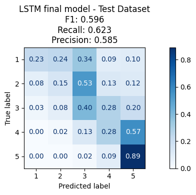

```python
displayConfusionMatrix(y_test, y_pred_test, model='LSTM final model', data_set='Test')
```

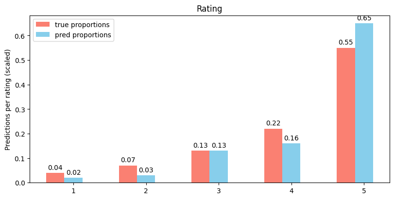

```python
plot_proportions(y_train, y_pred_test, None)
```

## Conclusion

### General takeways

One big takeway from this problem attempt is that just adding more layers of a given unit (GRU, LSTM, etc) or more layers at all to an RNN is not going necessarily going to improve any of the metrics used to assess model predictive power or accuracy. For instance, one of the problematic features of RNN's layers is vanishing/exploding gradient problem, which can be addressed by adding dropout layers with different dropout rates between cells. In the architectures tested here, 3 of the 4 optimal sets of hyperparameters had some dropout layers with a 0.0 dropout rate, indicating they allowed the previous and following layers to remain fully connecetd. Additionally, when testing the affect of additional layers of GRU units, adding more layers did not improve model performance, even with parameter tuning

### Model performace helpers and detractors

On previous iterations of this problem challenge, I set the models to use accuracy score in the model compiler. I found this did not help because even though the accuracy scores and F1 scores did improve, the models did poorly when it came to predicting labels for reviews that were not 5 stars. By changing the scoring metric to multi-label AUC, I was able to modestly improve the model performances.

### Possible future improvements

Another possible way to improve the model performances would be to run more validation trials in the tuning process. Keras tuners allow you to train a batch of models for a given set of hyperparameters, then take the best scoring model and compare that to the other best performing hyperparameter sets. Runing 2 or more trials instead of just one would provide a more robust assessment of a given set of hyperparameters preformance with a model architecture.

## Acknowledgements

1. Koo Ping Shung (2018) Accuracy, Precision, Recall or F1?, Towards Data Science. Available at: https://towardsdatascience.com/accuracy-precision-recall-or-f1-331fb37c5cb9.

2. Akash Deep (2020) Understanding NLP Keras Tokenizer Class Arguments with example. Medium. Available at: https://medium.com/analytics-vidhya/understanding-nlp-keras-tokenizer-class-arguments-with-example-551c100f0cbd.